# 1. Introduction

The `diem` package provides a lightweight solution to clean up single-cell data during the pre-processing step. The purpose of `diem` is to remove droplets that contain extranuclear or extracellular RNA. `diem` is designed for droplet-based single-cell RNA-seq and has been tested on 10X Chromium data.

This tutorial will use the publicly available 10X single-nucleus RNA-seq data that was generated from fresh mouse brain tissue. We will use a subset of the data that is available with the package. The full data set is available [here](https://support.10xgenomics.com/single-cell-gene-expression/datasets/2.1.0/nuclei_2k).

# 2. Data input

`diem` takes as input the raw counts from a droplet-based single-cell experiment such as from 10X. Since the raw data consists of roughly 20,000 genes and over 100,000 droplets, the counts data has to be stored as a sparse matrix from the R package [Matrix](https://cran.r-project.org/web/packages/Matrix/index.html). Furthermore, `diem` takes advantage of the matrix manipulation functions in the `Matrix` package to speed up computations. The R object that wraps data access and the `diem` functions is the `SCE` object. It is important to note here that `diem` works best when all droplets generated by the experiment are included, even those with only 1 read mapping to a gene. They provide extensive information on the RNA profile of the background distribution.

If you have 10X data that has been aligned with [CellRanger](https://support.10xgenomics.com/single-cell-gene-expression/software/pipelines/latest/what-is-cell-ranger), then the raw data will be stored in `outs/raw_feature_bc_matrix` in the output directory (for CellRanger v3). We provide a convenience function `read_10x` that can read the 10X output into a sparse Matrix.

```r
library(diem)

# In the diem directory
counts <- read_10x("../tests/testdata/")
dim(counts)
```

```
#> [1] 1001 2457
```

```r
class(counts)
```

```
#> [1] "dgCMatrix"
#> attr(,"package")
#> [1] "Matrix"
```

This function reads in the counts present in the `tests/testdata` directory into a sparse matrix. This subset of the mouse brain raw data from 10X contains 1,001 genes and 2,457 droplets.

The raw counts in a sparse matrix forms the starting point for pre-processing with `diem`. To create the `SCE` object:

## 2.1 Creating an SCE object

```r
mb_small <- create_SCE(counts, name="MouseBrain")
dim(mb_small)
```

```
#> [1] 1001 2457
```

```r
class(mb_small)
```

```
#> [1] "SCE"
#> attr(,"package")
#> [1] "diem"
```

The SCE object `mb_small` stores the counts as well as the meta data on the droplets:

```r
drop_data <- droplet_data(mb_small)
head(drop_data)
```

```
#>                  total_counts n_genes
#> CTCATTATCAACTCTT          801     234
#> CTTACCGTCTCAAACG          436     242
#> TGACAACGTCCGACGT          540     284
#> ATAAGAGAGTCTCGGC          667     372
#> TTGACTTTCGCCAGCA          163     110
#> GGGACCTGTGTAATGA          344     149
```

```r
summary(drop_data)
```

```
#>   total_counts       n_genes
#>  Min.   :  54.0   Min.   :  9.00
#>  1st Qu.:  92.0   1st Qu.: 27.00
#>  Median : 181.0   Median : 41.00
#>  Mean   : 323.4   Mean   : 82.36
#>  3rd Qu.: 389.0   3rd Qu.: 77.00
#>  Max.   :5375.0   Max.   :705.00
```

## 2.2 Plotting quality metrics

Useful diagnostics for assessing droplets include the percent of reads that align to the mitochondrial genome, in addition to percent that align the nuclear-localized MALAT1. We can generate this using the following:

```r
mt_genes <- grep(pattern = "^mt-", x = rownames(mb_small@gene_data),
                 ignore.case = TRUE, value = TRUE)
mb_small <- get_gene_pct(x = mb_small, genes = mt_genes, name = "pct.mt")
genes <- grep(pattern = "^malat1$", x = rownames(mb_small@gene_data),
              ignore.case = TRUE, value = TRUE)
mb_small <- get_gene_pct(x = mb_small, genes = genes, name = "MALAT1")
drop_data <- droplet_data(mb_small)
summary(drop_data)
```

```
#>   total_counts       n_genes           pct.mt           MALAT1
#>  Min.   :  54.0   Min.   :  9.00   Min.   : 1.671   Min.   : 0.000
#>  1st Qu.:  92.0   1st Qu.: 27.00   1st Qu.:53.698   1st Qu.: 0.277
#>  Median : 181.0   Median : 41.00   Median :76.763   Median : 1.235
#>  Mean   : 323.4   Mean   : 82.36   Mean   :67.442   Mean   : 3.614
#>  3rd Qu.: 389.0   3rd Qu.: 77.00   3rd Qu.:89.493   3rd Qu.: 3.509
#>  Max.   :5375.0   Max.   :705.00   Max.   :98.701   Max.   :70.528
```

Before filtering, it's good plot the distribution of reads and MT%.

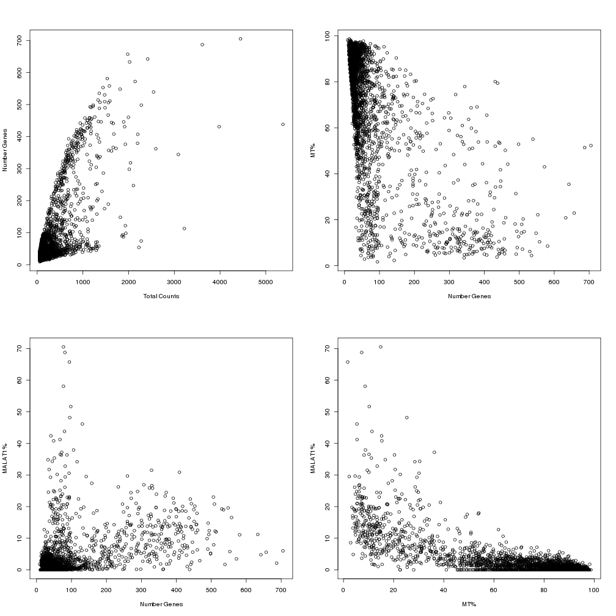

```r
datf <- drop_data
par(mfrow=c(2,2))
plot(datf$total_counts, datf$n_genes,
     xlab="Total Counts", ylab="Number Genes")
plot(datf$n_genes, datf$pct.mt,
     xlab="Number Genes", ylab="MT%")
plot(datf$n_genes, datf$MALAT1,
     xlab="Number Genes", ylab="MALAT1%")
plot(datf$pct.mt, datf$MALAT1,
     xlab="MT%", ylab="MALAT1%")
```

The data suggests we can separate out 2 clusters, consisting of one low count/high MT% cluster, and one high count/low MT% cluster.

# 3. Running DIEM

The following outlines the steps involved in `diem`:

1. Estimating the initial number of clusters, as well droplets within these clusters in order to initialize the multinomial means.
2. Run EM to estimate the parameters of the multinomial mixture model.
3. Classify droplets based on their likelihood.

## 3.1 Specifying test and debris droplets

To run `diem`, we first have to specify which droplets we would like to:

1. classify
2. fix as debris
3. initialize clustering

1 and 2 are mutually exclusive, while 3 is a subset of 1. It is helpful to use the above plots, as well as a barcode-rank plot, to determine the droplet sets.

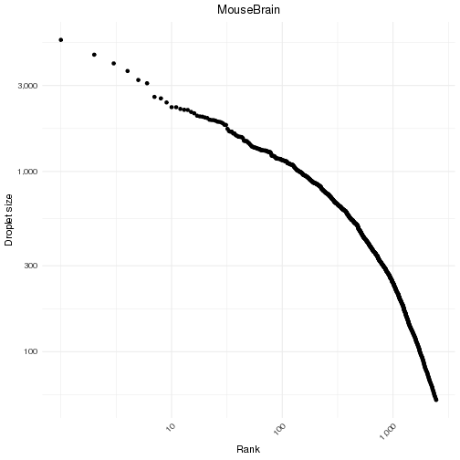

```r
barcode_rank_plot(mb_small, title = "MouseBrain")
```

Since this is only a subset, the tail of the low-count droplets in the barcode-rank plot is much smaller. Typical data sets will have tens to hundreds of thousands of droplets more than what is shown here. The choice of the cutoff to fix debris and classify droplets is somewhat arbitrary and depends on subjective interpretation of what will likely be included in the debris. We should select the cutoff to fix as much of the debris droplets into the debris group, while allowing to classify droplets that may contain cells or nuclei. To set the groups, we use the function `set_debris_test_set`:

```r
mb_small <- set_debris_test_set(mb_small,
                                top_n = 2000,
                                min_counts = 100,
                                min_genes = 100)
length(mb_small@test_set)
```

```
#> [1] 457
```

```r
length(mb_small@bg_set)
```

```
#> [1] 2000
```

This results in 457 test droplets and 2,000 debris droplets. The function call states that the test set (droplets to classify) must have at least 100 total counts and 100 genes detected. Furthermore, only consider the top 2,000 droplets ranked by counts. Anything below this, regardless of total counts and genes detected, will be fixed to debris. This option isn't necessary here but we put it here to illustrate it. This can help with variable total counts when we have a good approximation of the maximum number of nuclei or cells that can be captured. To turn this off, set `top_n = Inf`.

## 3.2 Filtering genes

Now that we set the test and debris droplets, we remove lowly expressed genes. We use counts per million mapped reads (CPM) to set the filtering criteria.

```r
mb_small <- filter_genes(mb_small, cpm_thresh = 10)
genes <- gene_data(mb_small)
summary(genes)
```

```
#>       mean           total_counts         n_cells        exprsd
#>  Min.   : 0.02239   Min.   :    55.0   Min.   :  52.0   Mode:logical
#>  1st Qu.: 0.05739   1st Qu.:   141.0   1st Qu.: 120.0   TRUE:1001
#>  Median : 0.07163   Median :   176.0   Median : 147.0
#>  Mean   : 0.32303   Mean   :   793.7   Mean   : 202.1
#>  3rd Qu.: 0.10582   3rd Qu.:   260.0   3rd Qu.: 201.0
#>  Max.   :41.20309   Max.   :101236.0   Max.   :2450.0
```

All genes are expressed here (since this is a subset including the expressed genes).

## 3.3 Initializing clusters

Before running EM on the multinomial mixture model, we need to estimate the number of mixtures and initialize the mean parameters for each multinomial. We do this by non-parametric clustering of of droplets that are likely to contain nuclei. Here we use the top 200 ranked by gene to estimate the cell types. Alternatively, you can `order_by = "count"`.

```r
mb_small <- set_cluster_set(mb_small,
                            cluster_n = 200,
                            order_by = "gene")
length(mb_small@cluster_set)
```

```
#> [1] 203
```

The number of cell types are estimated by running Louvain clustering on the cluster set defined above. Briefly, this involves extracting the variable genes, normalizing the counts, generating a weighted k-nearest graph, and clustering the graph. This is done with a single function `initialize_clusters`. You can use variable genes or all genes by setting the `use_var` parameter, along with setting the number of variable genes with `n_var`.

```r
mb_small <- initialize_clusters(mb_small,
                                use_var = TRUE,
                                n_var = 200,
                                verbose = TRUE)
```

```
#> Finding 30 nearest neighbors.
#> Done.
#> Initializing clusters.
#> Initialized k=3 cell types and 1 debris cluster.
```

This identified 3 distinct cell types in addition to the debris set. Now that we have the number of mixtures and their initializations, we can run EM to estimate the parameters and classify the droplets.

## 3.4 Running EM

Use the `run_em` function to estimate the parameters of the multinomial mixture and calculate droplet probabilities:

```r
mb_small <- run_em(mb_small, verbose = TRUE)
```

```
#> Running EM.
#> Iteration 1; llk -695548.951672126
#> Iteration 2; llk -695450.881961419
#> Iteration 3; llk -695381.454667752
#> Iteration 4; llk -695326.639974415
#> Iteration 5; llk -695301.724143541
#> Iteration 6; llk -695274.289283191
#> Iteration 7; llk -695265.382016337
#> Iteration 8; llk -695265.121966235
#> Iteration 9; llk -695263.457407499
#> Iteration 10; llk -695260.596730162
#> Iteration 11; llk -695260.269036709
#> Iteration 12; llk -695260.202167465
#> Iteration 13; llk -695260.199309534
#> Converged!
#> Finished EM
```

```r
drop_data <- droplet_data(mb_small)
summary(drop_data)
```

```
#>   total_counts       n_genes           pct.mt           MALAT1
#>  Min.   :  54.0   Min.   :  9.00   Min.   : 1.671   Min.   : 0.000
#>  1st Qu.:  92.0   1st Qu.: 27.00   1st Qu.:53.698   1st Qu.: 0.277
#>  Median : 181.0   Median : 41.00   Median :76.763   Median : 1.235
#>  Mean   : 323.4   Mean   : 82.36   Mean   :67.442   Mean   : 3.614
#>  3rd Qu.: 389.0   3rd Qu.: 77.00   3rd Qu.:89.493   3rd Qu.: 3.509
#>  Max.   :5375.0   Max.   :705.00   Max.   :98.701   Max.   :70.528
#>    CleanProb     Cluster   ClusterProb
#>  Min.   :0.000   1:2086   Min.   :0.9628
#>  1st Qu.:0.000   2: 163   1st Qu.:1.0000
#>  Median :0.000   3:  68   Median :1.0000
#>  Mean   :0.151   4: 140   Mean   :1.0000
#>  3rd Qu.:0.000            3rd Qu.:1.0000
#>  Max.   :1.000            Max.   :1.0000
```

This provides the probability that a droplet belongs to one of the k cell types or debris. The column `CleanProb` gives 1 minus the probability that the droplet belongs to the debris group. The `Cluster` column gives the group with the highest probability, while `ClusterProb` gives the probability of that cluster.

To classify a droplet as debris or nucleus/cell, set a threshold on `CleanProb`.

```r
mb_small <- call_targets(mb_small,
                         pp_thresh = 0.95,
                         min_genes = 100)
drop_data <- droplet_data(mb_small)
summary(drop_data)
```

```
#>   total_counts       n_genes           pct.mt           MALAT1
#>  Min.   :  54.0   Min.   :  9.00   Min.   : 1.671   Min.   : 0.000
#>  1st Qu.:  92.0   1st Qu.: 27.00   1st Qu.:53.698   1st Qu.: 0.277
#>  Median : 181.0   Median : 41.00   Median :76.763   Median : 1.235
#>  Mean   : 323.4   Mean   : 82.36   Mean   :67.442   Mean   : 3.614
#>  3rd Qu.: 389.0   3rd Qu.: 77.00   3rd Qu.:89.493   3rd Qu.: 3.509
#>  Max.   :5375.0   Max.   :705.00   Max.   :98.701   Max.   :70.528
#>    CleanProb     Cluster   ClusterProb         Call
#>  Min.   :0.000   1:2086   Min.   :0.9628   Clean : 371
#>  1st Qu.:0.000   2: 163   1st Qu.:1.0000   Debris:2086
#>  Median :0.000   3:  68   Median :1.0000
#>  Mean   :0.151   4: 140   Mean   :1.0000
#>  3rd Qu.:0.000            3rd Qu.:1.0000
#>  Max.   :1.000            Max.   :1.0000
```

This gives 371 clean droplets and 2,086 debris. The majority of the 2,086 droplets had very low counts and would have been excluded anyways. To see how many of the droplets with at least 100 genes detected were removed as debris, we can run the following:

```r
clean <- get_clean_ids(mb_small)
removed <- setdiff(mb_small@test_set, clean)
length(clean)
```

```
#> [1] 371
```

```r
length(removed)
```

```
#> [1] 86
```

```r
length(removed) / (length(removed) + length(clean))
```

```
#> [1] 0.1881838
```

This removed nearly 19% of the 457 test droplets. To see which droplets which were removed, we can plot the droplets colored by their probability.

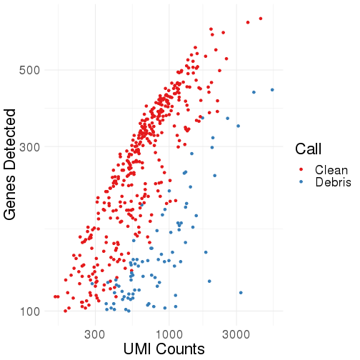

```r
plot_umi_gene_call(mb_small, alpha = 1)
```

We can also plot with MT% on one of the axes.

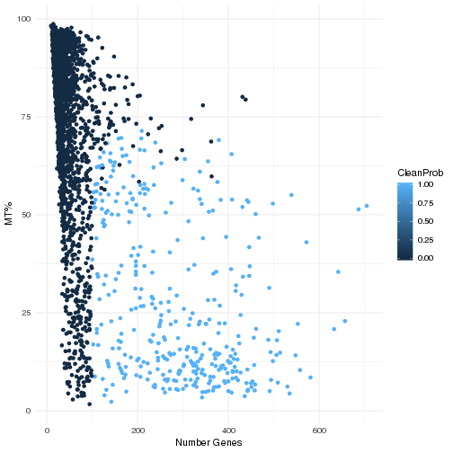

```r
library(ggplot2)
drop_data <- droplet_data(mb_small)
ggplot(drop_data, aes(x = n_genes, y = pct.mt, color = CleanProb)) +
geom_point() +
theme_minimal() +
xlab("Number Genes") + ylab("MT%")
```

The droplets removed tend to be those with high MT% and low UMI counts/ genes detected.

# 4. Downstream analysis

`diem` filtering provided a set of droplets we can use for downstream analysis. We can extract the droplets passing `diem` filtering as well as the counts.

```r
counts <- raw_counts(mb_small)
counts_clean <- counts[,clean]
dim(counts_clean)
```

```
#> [1] 1001  371
```

We also provide a convenience function for converting to a Seurat object:

```r
seur <- convert_to_seurat(mb_small,
                          targets = TRUE,
                          meta = TRUE,
                          min.features = 100)
dim(seur)
```

```
#> [1] 1001  371
```

```r
head(seur@meta.data)
```

```
#>                     orig.ident nCount_RNA nFeature_RNA total_counts
#> CTCATTATCAACTCTT SeuratProject        801          234          801
#> CTTACCGTCTCAAACG SeuratProject        436          242          436
#> TGACAACGTCCGACGT SeuratProject        540          284          540
#> ATAAGAGAGTCTCGGC SeuratProject        667          372          667
#> TTGACTTTCGCCAGCA SeuratProject        163          110          163
#> GGGACCTGTGTAATGA SeuratProject        344          149          344
#>                  n_genes   pct.mt    MALAT1 CleanProb Cluster ClusterProb
#> CTCATTATCAACTCTT     234 28.58926 26.217228         1       2   1.0000000
#> CTTACCGTCTCAAACG     242 14.90826  6.422018         1       2   1.0000000
#> TGACAACGTCCGACGT     284 22.77778  6.111111         1       2   0.9998527
#> ATAAGAGAGTCTCGGC     372 11.39430  1.799100         1       2   1.0000000
#> TTGACTTTCGCCAGCA     110 20.85890  7.975460         1       2   0.9999878
#> GGGACCTGTGTAATGA     149 30.52326  2.325581         1       3   1.0000000
#>                   Call
#> CTCATTATCAACTCTT Clean
#> CTTACCGTCTCAAACG Clean
#> TGACAACGTCCGACGT Clean
#> ATAAGAGAGTCTCGGC Clean
#> TTGACTTTCGCCAGCA Clean
#> GGGACCTGTGTAATGA Clean
```

# 5. Considerations

Since we only used a subset of the entire raw data that covers the transcriptome for this example, we modified many of the parameters to fit this. We recommend using the entire raw data set with default parameters, as this should be appropriate for most data sets.